# Orvac - impacts of surveillance visit

# 1 Preamble

Further to the brief document on the surveillance visits in ORVAC, here we look at the impact this approach has on parameter estimates derived from the data that we collect.

# 2 Data generating process

Is as before – exponential distribution. Here we use rates such that the medians are 30 and 37 months in the control and treatment arms respectively.

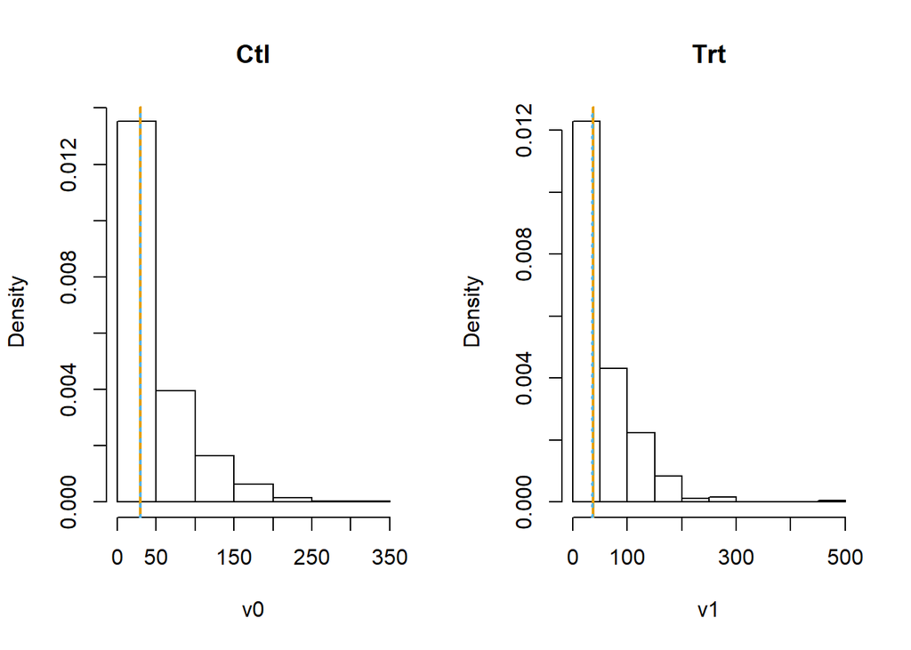

Figure 1. Underlying time to event data (solid vertical is true value, dashed is sample estimate)

# 3 Censoring

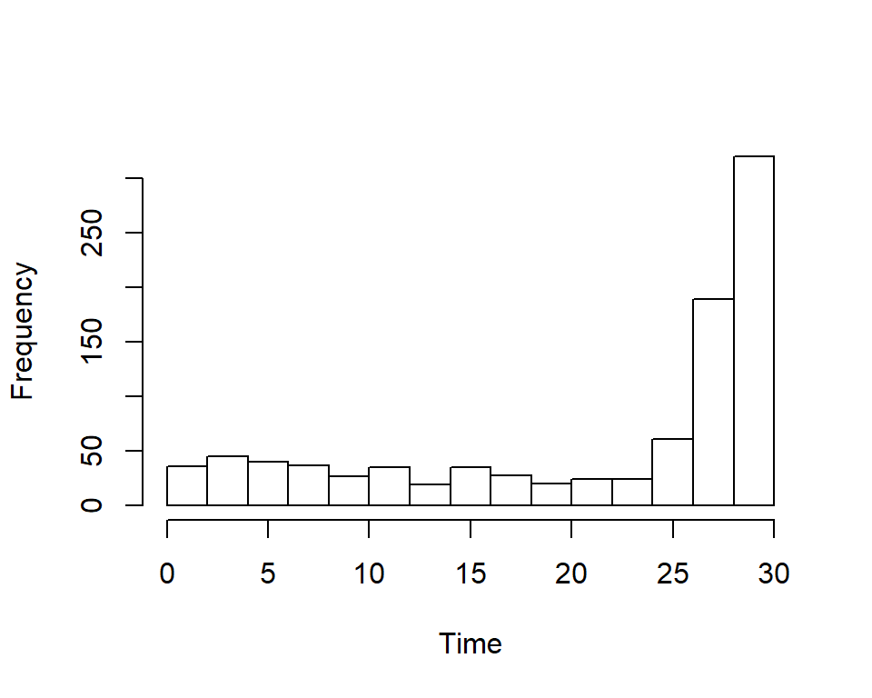

The ORVAC code has two implementations of censoring. The first is similar to the above, except that it also considers the time of the interim and time of accrual as well as age. The figure below compares the distribution of scale parameter estimates.

The histogram in the figure below shows the posterior distribution of the scale parameter under no censoring. The kernel density is the posterior from censored data (using the first censoring implementation in the ORVAC code) and the vertical dashed line is the true parameter values used to generate the data. Only a single dataset is being summarised so you wouldn’t expect these to line up exactly.

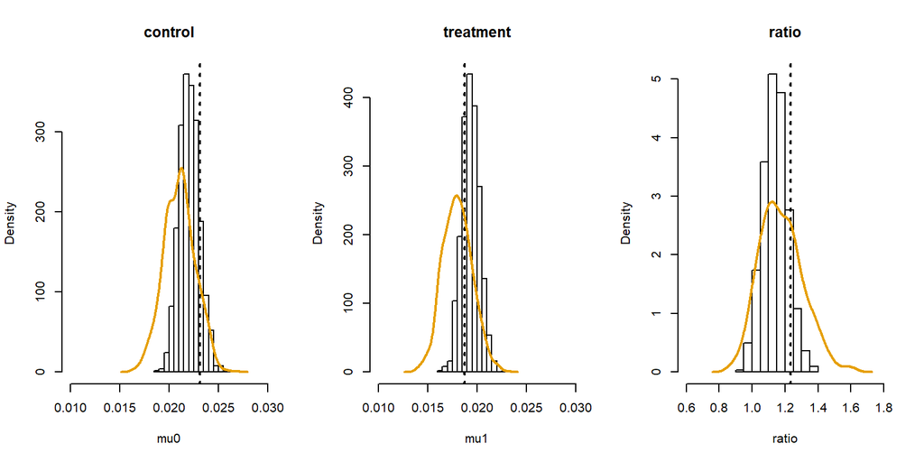

Figure 3. Parameter posteriors from censored data

The trial design is such that participants will be followed up at approximately 14-21 and 28-55 days and thereafter every 6 months (approximately) from randomisation. This logic (including the stochastic aspects) is implemented in the second approach to censoring in the ORVAC code. The figure below compares the distribution of the parameter estimates under the second ORVAC visit-based censoring implementation.

The histogram in the figure below shows the posterior distribution of the scale parameter under no censoring. The kernel density is the posterior from censored data (using the second censoring implementation in the ORVAC code that incorporates the visit regimes) and the vertical dashed line is the true parameter values used to generate the data. Again, only a single dataset is being summarised so you wouldn’t expect these to line up exactly.

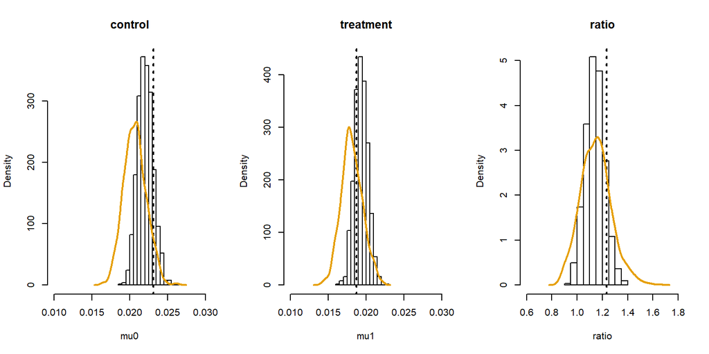

Figure 4. Parameter posteriors from censored data

The above figures show that the different estimators are approximately aligned, but the repeat-nature of the estimators are used to assess bias.

The figure below shows the results from a simulation examining the repeat-nature of the estimators. The histograms show the distribution of the mean of the posterior under no censoring computed at each iteration of the simulation. The kernel density shows the distribution of the mean of the posterior under the ORVAC visit-based censoring and the black dashed vertical lines show the true parameter values. The distributions now line up reasonably well with the true values, but the ORVAC censoring is more spread out than the uncensored version. We would expect this to be the case as the uncensored data contains more information and therefore the resulting posterior of the parameter estimates is more precise.

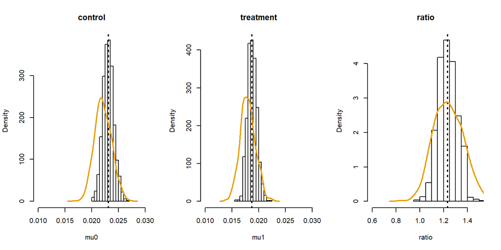

Figure 5. Parameter posteriors from censored data simulated 1000 times

# 4 Posterior predictive distribution

We can generate the posterior predictive distribution of the scale parameter by sampling from the posterior distributions for the scale parameter in each arm and then using these draws to generate data under the exponential distribution. The predictive distributions serve as a means to simulate future data. In turn, the simulated data is used to assess how many trials would end up successful if we ran the current trial to its maximum sample size.

```
## [1] 0.645
```

```
## [1] 0.419
```

The figures below show the posterior estimates for the ratio of scale parameters generated for 1000 simulations using the posterior predictive distribution. The distributions derived from the uncensored data is more precise than the ORVAC, but again, we would anticipate that this would be the case.

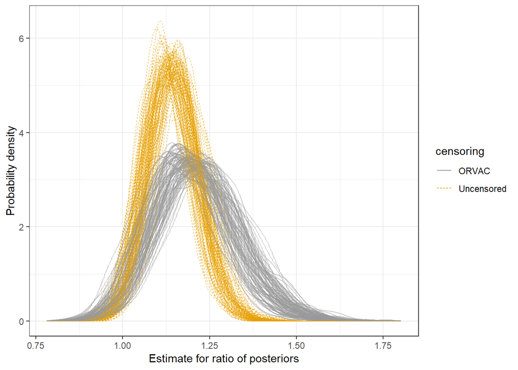

Figure 6. Ratios estimated from simulated trials using the posterior predictive distributions for time to events

# 5 Conclusion

The results look reasonable and I can proceed with the simulations again.